# Tree Models

Applied Machine Learning in Economics

We can use tree-based models for regression and classification problems. In short, these models split up our sample space (where our $X$-variables live) into rectangles. See Figure 8.2 in our textbook for an example. Each rectangle receives the same predicted value: either the mean of all $y$-variables in that rectangle if it is a regression problem or the class with the largest representation in said rectangle.

# 1 Setup

First up, let’s attach some packages, load a dataset, set our seed, and sample-split; the usual points of business.

```r
library(tree)
library(tidyverse)
set.seed(490)

ahs = read.csv('C:/Users/johnj/Documents/Data/Applied ML ECON490/lecture data/lecture data continuous.csv') %>%
  as_tibble # for old times sake

train = sample_frac(ahs, 0.5)
test  = anti_join(ahs, train, by = 'id')
```

# 2 Classification Tree

We start off with a classification tree predicting `beds`. In order to have the function `tree()` fit a classification tree, we need to convert the $y$-variable into a `factor`, even if the original is a `character` class.

## 2.1 Fitting

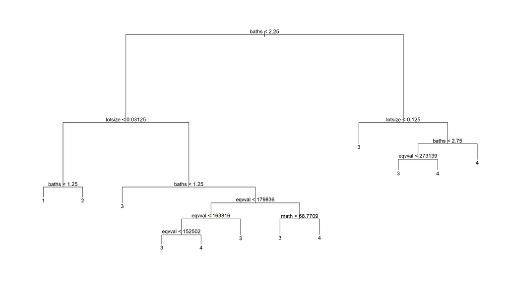

```r
fit_tree = tree(as.factor(beds) ~ ., train)

plot(fit_tree)
text(fit_tree, pretty = 0)
```

Above is the visual representation of a tree-based model; a decision tree.

**Sidebar**: every winter holiday I set up a green Christmas decision tree on my wall for activities to do conditional on the weather.

[figure not shown]

An important feature about decision trees is that they are sensitive to the initial conditions, i.e. small perturbations in the data they are trained on will lead to different predictions.

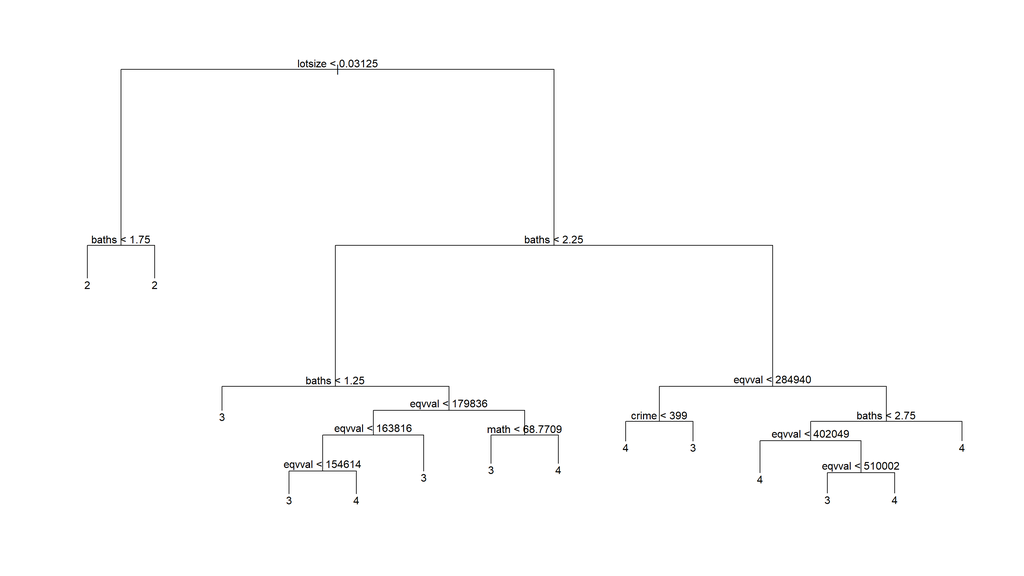

```r
train = sample_frac(ahs, 0.5)
test  = anti_join(ahs, train, by = 'id')

fit_tree = tree(as.factor(beds) ~ ., train)

plot(fit_tree)
text(fit_tree, pretty = 0)
```

Notice that `baths` and `lotsize` switched, and we have added `crime` as a variable. Regardless, we can still predict with this model.

```r
yhat = predict(fit_tree, test, type = 'class')
tbl = table(yhat, test$beds)
tbl
```

```
##
## yhat    0    1    2    3    4    5
##    0    0    0    0    0    0    0
##    1    0    0    0    0    0    0
##    2    8  139  425  152   26    4
##    3    0   36  432 1742  237   46
##    4    0    1   66  291  919  245
##    5    0    0    0    0    0    0
```

```r
sum(diag(tbl))/sum(tbl)
```

```
## [1] 0.6470958
```

An accuracy of 2/3 is not anything to be proud about, but it appears to be better than randomly guessing.

## 2.2 Pruning

Tree-based models also suffer from over fitting. To deal with this, we *prune* the trees. The math of pruning turns out to be quite similar to LASSO, which cross-validation to the rescue! Unfortunately, `caret` does not have an option for tree models, so we will use what is built in to the `tree` package. We are following lab 8.3 rather closely.

```r
fit_tree_cv = cv.tree(fit_tree, FUN = prune.tree)

fit_tree_cv
```

```
## $size
##  [1] 14 13 12 11  9  5  4  3  2  1
##
## $dev
##  [1]  8159.497  8456.089  8519.190  8571.747  9323.803  9646.902 10200.906
##  [8] 10224.528 11397.888 12626.069
##
## $k
##  [1]      -Inf  148.0517  153.2998  169.2203  193.1071  212.4787  246.0408
##  [8]  263.1595 1060.1648 1324.7193
##
## $method
## [1] "deviance"
##
## attr(,"class")
## [1] "prune"         "tree.sequence"
```

Here the hyperparameter `$k` is similar to $\lambda$ from LASSO. The deviance is given by
$$-2 \sum_m \sum_k n_{m,k} \text{log}(\hat{p}_{m,k})$$
where $m$ denotes terminal nodes (leaves), $k$ denotes class, $n_{m,k}$ is the number of observations for each $m$, $k$ combination, and $\hat{p}_{m,k}$ is the proportion of training observations in each $m$, $k$ combination.

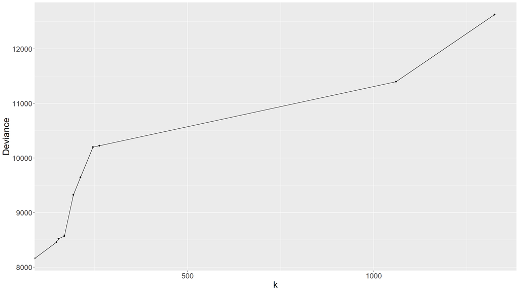

```r
df_tree = data.frame(Deviance = fit_tree_cv$dev, k = fit_tree_cv$k)
ggplot(df_tree, aes(x = k, y = Deviance)) +
  geom_line() +
  geom_point() +
  theme(text = element_text(size = 20))
```

It somewhat surprisingly looks like the unrestricted model performs the best with 14 leaves. Let’s fit it.

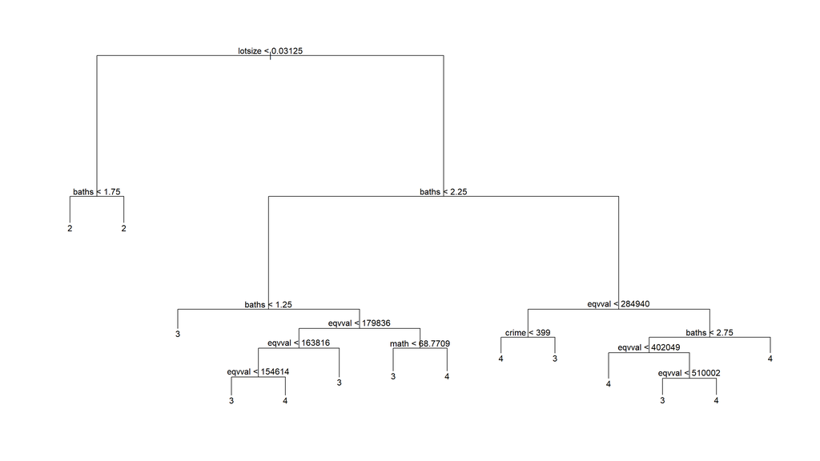

```r
fit_best = prune.misclass(fit_tree, best = 14)
plot(fit_best)
text(fit_best)
```

Wait, this looks like the same model! Well, that’s because it is. What we just did above was demonstrating how to prune an individual tree.

# 3 Regression Trees

Fitting a regression tree is largely the same motions as a classification tree, except:

1. we prune with `prune.tree()`
2. $y$ should be `numeric`
3. $\hat{y}$ is the mean of $y$ in each region

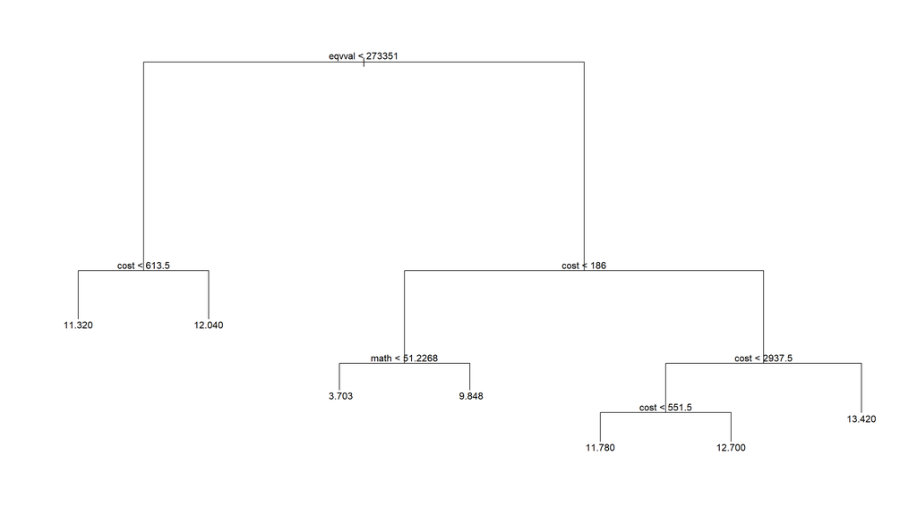

```r
fit_tree = tree(log(value) ~ ., train)
fit_tree_cv = cv.tree(fit_tree) # default is prune

i = which.min(fit_tree_cv$dev)
optm_size = fit_tree_cv$size[i]

fit_best = prune.tree(fit_tree, best = optm_size)

plot(fit_best)
text(fit_best)
```